# Controller Software Design

This Jupyter notebook describe the controller design for the USV. The object-oriented programming technique is implemented. The following sections are provided for this goal.

## Table of Content

- Loading dependency packages
- Controller design
- Boat modelling
- Simulation and testing

## Loading dependency packages

```python
from scipy import integrate, misc
import numpy as np
from numpy import matmul, diag, array, meshgrid, ones, zeros
from numpy.random import rand

import scipy.ndimage as ndimage

from matplotlib import animation
from matplotlib.offsetbox import OffsetImage, AnnotationBbox
import matplotlib.image as mpimg
import matplotlib.pyplot as plt
import mpl_toolkits.mplot3d.axes3d as p3
import ffmpy
```

## Controller design

We use the real-time environment `simpy` in the python to enable us to apply control input to the boat in the real time. Every controller is an object of the controller class with

```
  attributes:
```

**real_time_environment**: a `simpy` environment object

**feedback law**: a function that gets the states and returns control inputs

```
  methods:
```

**get_state(boat)**: a function that gest the sate of the boat

**find_input()**: a function that calculates the input to the boat

```python
class controller:
    def __init__(self, real_time_environment, feedback_law):
        self.env = real_time_environment
        self.law = feedback_law

    def get_state(self, boat):
        self.state = boat.state

    def find_input(self):
        feedback_law = self.law
        control_input = feedback_law(self.sate)
        return control_input
```

## Boat modelling

in this section, a software model of the boat is developed to interact with the controller. Similarly, a `simpy` environment is created for real-time interaction with the controller. We start with a **boat** class, an object of this class will have all the futures and functionality of the boat including:

```
attributes:
```

**real_time_environment**: a `simpy` environment object

**initial_state**: initial state of the boat is initialized using a python dictionary containing initial coordinate and velocities with this convection: `initial_state={'x0':0, 'y0':0, 'psi0':0,'u0':, 'v0':0, 'r0':0}`.

```
methods:
```

**drive(controller, time)**: This method drives the boat under a **controller** input for the duration of **time**.

```python
class boat:

    def __init__(self, real_time_environment, initial_state={'x0':0, 'y0':0, 'psi0':0,'u0':0, 'v0':0, \
        'r0':0}, parameters={'length':1, 'time_increment':0.1}):
        self.env = real_time_environment
        self.length = parameters['boat length']
        self.time_increment = parameters['time_increment']
        self.state = initial_state
        self.x0 = initial_state['x0']
        self.y0 = initial_state['y0']
        self.psi0 = initial_state['psi0']
        self.u0 = initial_state['u0']
        self.v0 = initial_state['v0']
        self.r0 = initial_state['r0']

    def drive(self, controller, time):
        controller.get_state(self)
        control_input = controller.find_input()

        def Dstate_Dt(state, t, control_input):
            u, v, r, x, y, psi = state
            Tu, Tr, Tf = control_input

            Du = Tu(t) + v*r
            Dv = -u*r
            Dr = Tr(t)
            Dx = u
            Dy = v
            Dpsi = r

            Dstate_Dt = [Du, Dv, Dr, Dx, Dy, Dpsi]
            return Dstate_Dt

        timeframe = [self.env.now, self.env.now + self.time_increment]
        sol = integrate.odeint(dp_dt, [self.u0, self.v0, self.r0, self.x0, self.y0, self.psi0], timeframe,\
            control_input)

        self.u = sol[:, 0]
        self.v = sol[:, 1]
        self.r = sol[:, 2]
        self.x = sol[:, 3]
        self.y = sol[:, 4]
        self.psi = sol[:, 5]
        self.env.timeout(self.env.now + self.time_increment)


    def animate(self, FileName, Realtime=False):
        fig = plt.figure()
        im = plt.imread('boat2.png')
        y_min, y_max = [-10, 10]
        x_min, x_max = [-10, 10]
        ax = plt.axes(xlim=(x_min,x_max), ylim=(y_min,y_max))
        time=ax.annotate('$time=$0',xy=(-9, 9))
        line, = ax.plot([], [], lw=2)

        plt.xlabel('$x$')
        plt.ylabel('$y$')

        plotcols = ["blue" , "red", "red"]
        plotlabels = ["Center" , "Front", "End"]
        plotlws = [3, 1, 1]
        plotmarkers = ['o','*','.']
        lines = []

        for index in range(3):
            lobj = ax.plot([],[], 's', lw=plotlws[index], marker=plotmarkers[index], color=plotcols[index], label=plotlabels[index])[0]
            #ax.legend()
            lines.append(lobj)

        def init():
            for line in lines:
                line.set_data([],[])
            return lines

        global ann
        ann = []
        def animated(i,dt):
            global ann
            if ann:
                ann.remove()
            #for artist in plt.gca().lines + plt.gca().collections:
            #    artist.remove()

            L = self.length

            def rotate_image(path, degree):
                img = plt.imread(path)
                img = ndimage.rotate(img, degree)
                return OffsetImage(img, zoom=0.2)

            ann = AnnotationBbox(rotate_image('boat2.png', self.psi[i]*180/np.pi), (self.x[i], self.y[i]), frameon=False)
            ax.add_artist(ann)
            #ax.axis('off')
            #ann_list.append(ann)

            #newax = fig.add_axes([0, 0, L/10, L/10], anchor='C')
            #img_boat_rotated = ndimage.rotate(im, self.psi[i]*180/np.pi)
            #img_boat_rotated_shifted = ndimage.shift(img_boat_rotated, [self.x[i], self.y[i], 0])
            #newax.imshow(img_boat_rotated_shifted)
            #newax.axis('off')

            #xlist = [self.x[i], self.x[i]+L*np.cos(self.psi[i]), self.x[i]-L*np.cos(self.psi[i])]
            #ylist = [self.y[i], self.y[i]+L*np.sin(self.psi[i]), self.y[i]-L*np.sin(self.psi[i])]
            s=i*dt
            time.set_text('$time=$%2.1f'%s)
            #for lnum, line in enumerate(lines):
            #    line.set_data(xlist[lnum], ylist[lnum]) # set data for each line separately.
            #return lines

        path_mp4 = './mp4s/' + FileName + '.mp4'
        path_gif = './gifs/' + FileName + '.gif'

        dt = self.time[1]-self.time[0]
        t_max = self.time[-1]

        anim = animation.FuncAnimation(fig,lambda i: animated(i,dt), init_func=init,frames=int(t_max/dt), interval=0.1, blit=False)
        anim.save(path_mp4, fps=10, extra_args=['-vcodec', 'libx264'])
        ff = ffmpy.FFmpeg(inputs = {path_mp4:None} , outputs = {path_gif: None})
        ff.run()

        if Realtime:
            anim.show()
```

## Simulation and testing

[output not shown]

```
10.0
```

[output not shown]

[output cut: 43 more lines]

[output not shown]

[output not shown]

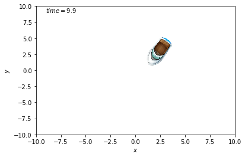

```python
myboat = boat(0,0,0,0,0,0)
def Tu(t):
    return np.sin(t)
def Tr(t):
    return np.sin(t)
myboat.drive(Tu,Tr,10)
print(myboat.time[-1])
myboat.animate("animation22", Realtime=True)
```